# Correlation and Linear Regression

2024-03-20

## Introduction

## Introduction

- Who are we?
  - IMBEI Biostatistics and Bioinformatics Department
  - Statistical consulting for various types of studies
  - Working on larger Health Services Research (“Versorgungsforschung”) projects
  - Background in Mathematics (Philipp) and Economics and Survey Statistics (Robert)
- Who are you?
  - Name, background, current projects…

## Where in this course series are we?

- Introduction: R and descriptive statistics with R
- Statistical tests with R
- ANOVA with R
- **Regression models with R**

## Why correlations and regression models?

- Many features of scientific interested can be measured as continuous variables
- In medical applications, study endpoints can often be decoded as binary variables
- Very often we are interested in **relationships** between two or more variables
- Correlation methods and regression models allow us to quantify these relationships!

## Structure of this course

- Generally: **First theory then practice** (presentations + tutorials)
- Correlations
- Linear regression models
- *Lunch break*
- Logistic regression models
- Model assessment and more advanced modelling techniques
- GpraphPad Prism

## R tutorials and markdown scripts

- We will provide you with the solved version at the end of the course
- R Markdown scripts can be used as templates for **your** future projects
- You can always talk to an IMBEI biostatistician…

## Correlations

## What is a correlation coefficient?

- A **descriptive** statistic
- Summarises information on a sample of observations
- Each observation has to consist of (at least) two measured features
- Observations have to be **independent** of one another
- Measurements have to be at least on an ordinal scale

## A first example

- Observations of speed and stopping distance of cars
- Speed in *mph*, distance in *ft* (1920s cars)

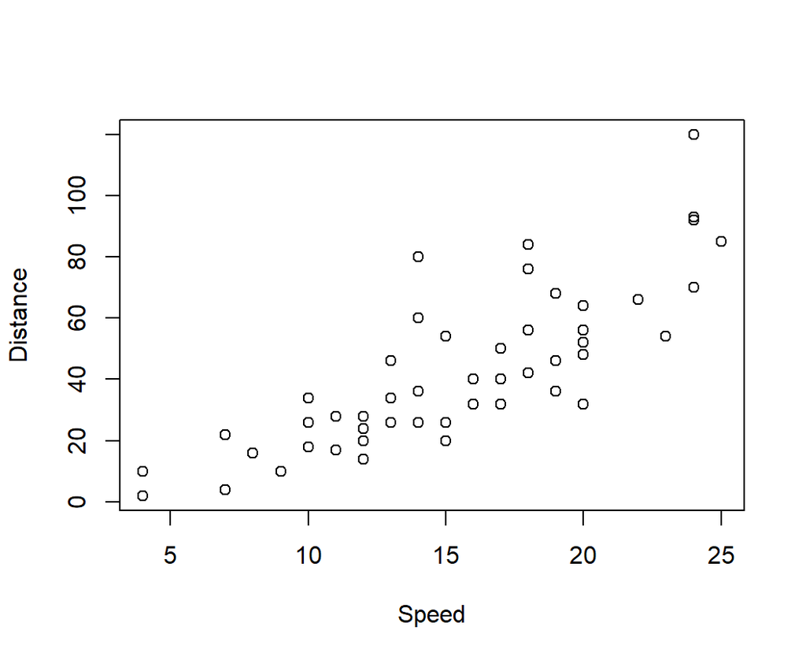

## Another example

- Coma patients and their cognitive recovery (Wong et al, 2001)
- Age at time of injury and verbal IQ score after waking up

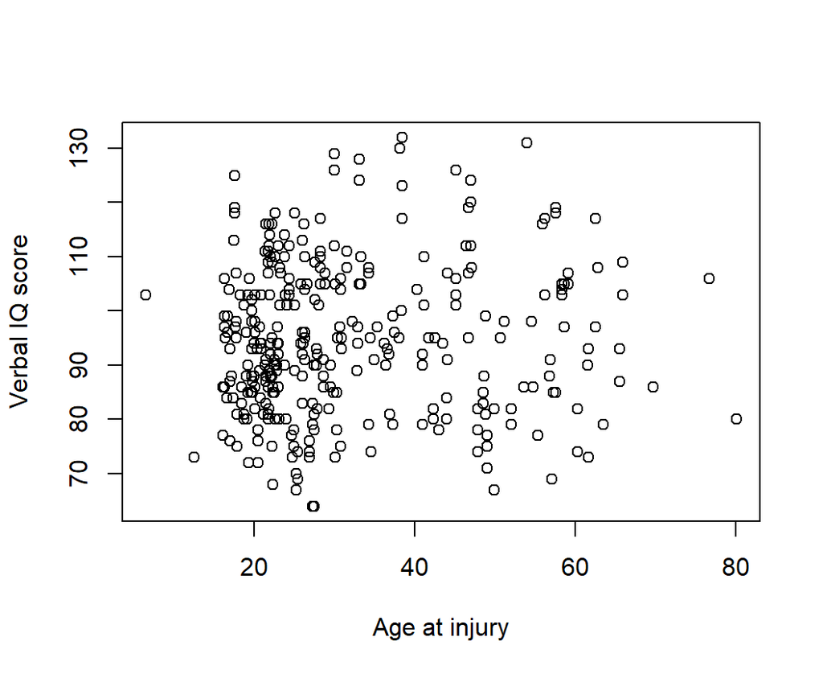

## How can we measure these relationships?

- We want to decribe the shape of this cloud of observations in one coefficient
- This coefficient should be independent of the scale of measurements
- We want it to take values between 0 and 1 (plus the sign for the “direction”)

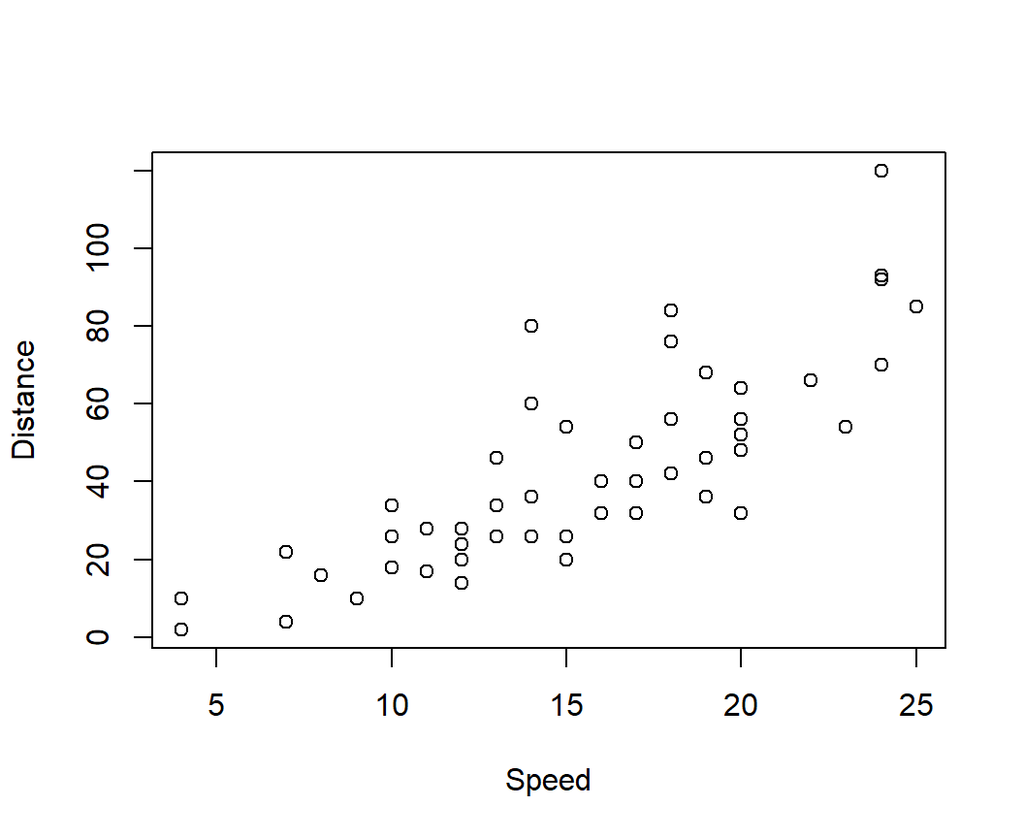

## How can we measure these relationships?

- Starting with the means of the two variables
- We want to calculate the variation in the “y = x”-direction… and compare to the total variation of both variables

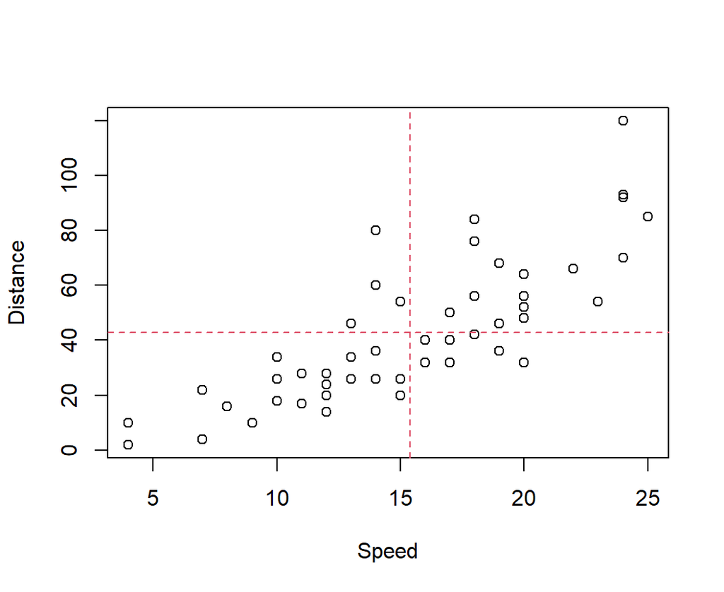

## Pearson’s Correlation Coefficient

- A.k.a. Product-Moment Correlation, Pearson’s r, “correlation”
- In \([-1, 1]\)
- A measure of the strength of *linear relationship* between two variables

\[ r = \frac{\text{Cov}(x,y)}{\sqrt{\text{Var}(x)\text{Var}(y)}} = \frac{\sum \left ( x_{i} - \overline{x} \right ) \left ( y_{i} - \overline{y} \right )}{\sqrt{\sum \left ( x_{i} - \overline{x} \right )^{2} \sum \left ( y_{i} - \overline{y} \right )^{2}}} \]

## Spearman’s Rank Correlation Coefficient

- A.k.a. Rank Correlation, Spearman’s Rho
- In \([-1, 1]\)
- A measure of the strength of any *monotone relationship* between two variables
- Is equal to Pearson’s Correlation calculated from the **ranks of observations** (smallest value = rank \(1\))

| Speed (in mph) | 9 | 10 | 10 | 10 | 11 |
| --- | --- | --- | --- | --- | --- |
| Speed rank | 1 | 3 | 3 | 3 | 5 |

## Pearson versus Spearman

- Pearson: **linear** - Spearman: **monotone**
- Both can be used for inferential statistics
- Pearson has more assumptions, mainly that both variables are approximately normally distributed.
- If assumptions are met, Pearson is more powerful, i.e. better in detecting non-zero correlations

## Linear Regression

## Regression

### main idea:

Express a response variable \(y\) as a function \(f\) of a set explanatory variables \(x:=(x_1,\ldots,x_p)\):

\[ \text{response} = f(\text{explanatory variables}) + \text{error term} \] Notation: \[ y = f(x) + \epsilon \]

- some assumptions about \(\epsilon\): usually independent normally distributed error with mean zero
- The type of \(f\) is assumed (e.g.: linear, polynomic, \(\ldots\))
- But: \(f\) is unknown

## Regression - Example

Suppose you want to use the **NHANES** data to investigate the relationship between age `Age` and total cholesterol `Totchol`

```r
nhanes[,c("Age","TotChol")]
```

```
##         Age TotChol
##    1: 34.08    3.49
##    2: 34.08    3.49
##    3: 34.08    3.49
##    4: 49.67    6.70
##    5: 45.08    5.82
##   ---
## 2228: 34.17    3.54
## 2229: 20.25    4.60
## 2230: 37.42    5.15
## 2231: 43.58   13.65
## 2232: 48.92    6.36
```

Then

- `TotChol` is the response
- `Age` is the (only) explanatory variable \(x_1\)

## Regression in general

### main goal:

- Find an estimate \(\widehat f\) for the the function \(f\).
- Use \(\widehat f\) to gain insight into the relationship between \(y\) and \(x\).

### two main types of applications:

- to make predictions (forecasts) on individuals
- to assess explained variation in the response by influential variables

## Simple Linear Regression

- `simple` \(\Rightarrow\) only one explanatory variable \((p=1)\)
- `linear` \(\Rightarrow\) \(f\) is a linear function in \(x\)

\[ y =f(x) + \epsilon = \beta_0 + \beta_1 \cdot x + \epsilon \]

- \(\beta_0\) is called **Intercept**,
- \(\beta_1\) is the **coefficient** of \(x_1\).
- But: \(\beta_0\) and \(\beta_1\) are unknown (!)

## Simple Linear Regression

### Aim:

To get estimates \(\widehat\beta_0,\widehat\beta_1\) for \(\beta_0,\beta_1\) from data, such that for observations \(i \in \{1,\ldots,n\}\) the fitted values \(\widehat y_i\) \[\widehat y_i = \widehat f (x_{1i})=\widehat \beta_0 + \widehat\beta_1\cdot x_{1i}\] are “close” to the real response \(y_i\).

### Method:

Choose a fitting approach: Minimization of the **residual sum of squares (RSS)**: \[ \text{RSS} := \sum_{i=1}^n \Big( y_i - \underbrace{\widehat y_i}_{= \widehat f(x_{1i})}\Big)^2 \]

## Simple Linear Regression

Minimization of the **RSS**: \[ \widehat\beta_0,\widehat\beta_1= \underset{\tilde\beta_0,\tilde\beta_1 \in \mathbb{R}^2}{\operatorname{argmin}} \Big( \sum_{i=1}^n \big( y_i - (\tilde\beta_0 + \tilde\beta_1x_{i})\big)^2 \Big) \]

Solution \[\begin{array} \hbox{}\widehat\beta_1 &=\frac{\sum_{i=1}^n(x_i-\overline{x})(y_i-\overline{y})} {\sum_{i=1}^n (x_i-\overline{x})^2} \quad = \frac{\text{Cov}(x,y)}{\text{Var}(x)} = r_{xy}\frac{\text{sd}_y}{\text{sd}_x}\\[2ex] \widehat {\beta_0}&=\overline{y}-\widehat\beta_1 \cdot \overline x \end{array}\]

So in simple linear regression, \(\widehat\beta_1\) can be expressed with the Pearson’s correlation and the sample standard deviations of \(x\) and \(y\).

## Example `cholesterol`

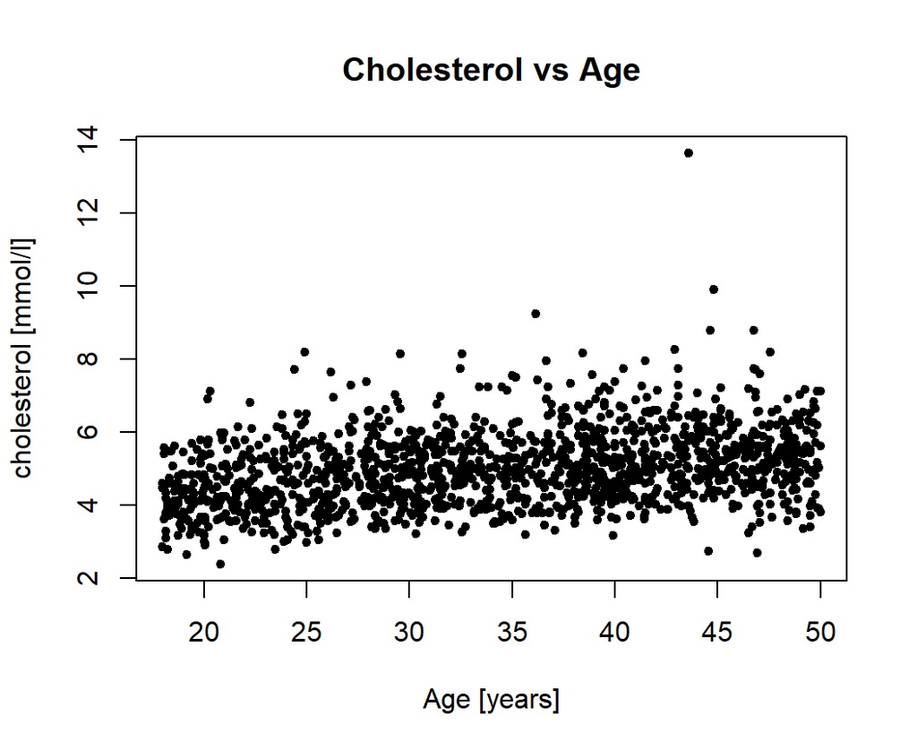

## Example `cholesterol`

### simple linear regression model – stats::lm()

```r
lm1 <- lm(TotChol ~ Age, data=nhanes)
print(lm1)
```

```
##
## Call:
## lm(formula = TotChol ~ Age, data = nhanes)
##
## Coefficients:
## (Intercept)          Age
##     3.78117      0.03523
```

Here \(\widehat\beta_0=\) 3.7811661 and \(\widehat\beta_1=\) 0.0352317

## Example `cholesterol`

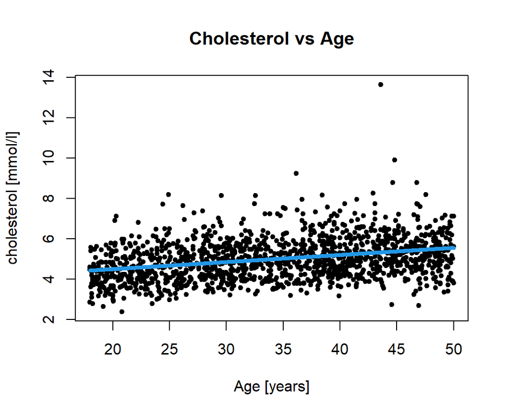

## Example `cholesterol`

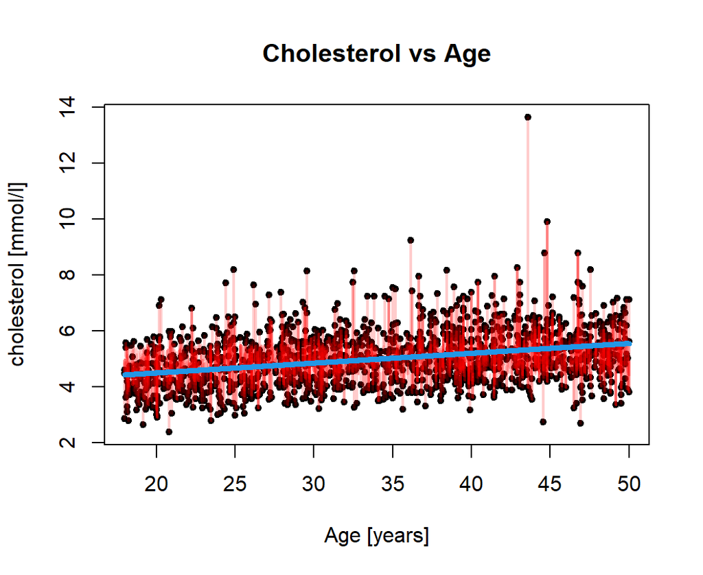

Each red line segment is the residual to the according observation \(i\):

\[ \hbox{}\widehat\epsilon_i = \text{TotChol}_i-\widehat f(\text{Age}_i) \] the squares of which are minimized.

## Simple Linear Regression

### Coefficient of determination \(R^2\)

is the proportion of variance in the response that is explained by the explanatory variable(s) \[ R^2 =1- \frac{\text{RSS}}{\text{TSS}} \] where **RSS** is the residual sum of squares  
and **TSS** is the total sum of squares: \[ \text{TSS} := \sum_{i=1}^n \Big( y_i - \overline y \Big)^2 \] In simple linear regression \(R^2\) is equal to the Pearson’s correlation squared: \[ R^2 = {r_{xy}}^2 \]

## Simple Linear Regression

### Inference in linear regression analysis

main types of hypothesis tests:

- moments-based: t-test / z-test
- variance-based model comparisons: F-test
- likelihood-based model comparisons

… more on that later

## Example `cholesterol`

### summary() - function in R

```
##
## Call:
## lm(formula = TotChol ~ Age, data = nhanes)
##
## Residuals:
##     Min      1Q  Median      3Q     Max
## -2.7442 -0.6654 -0.0842  0.5731  8.3334
##
## Coefficients:
##             Estimate Std. Error t value Pr(>|t|)
## (Intercept) 3.781166   0.081766   46.24   <2e-16 ***
## Age         0.035232   0.002288   15.40   <2e-16 ***
## ---
## Signif. codes:  0 '***' 0.001 '**' 0.01 '*' 0.05 '.' 0.1 ' ' 1
##
## Residual standard error: 0.972 on 2122 degrees of freedom
##   (108 Beobachtungen als fehlend gelöscht)
## Multiple R-squared:  0.1005, Adjusted R-squared:  0.1001
## F-statistic: 237.1 on 1 and 2122 DF,  p-value: < 2.2e-16
```

## Multiple Linear Regression

Multiple explanatory variables \(x:=x_1,\ldots,x_p\)

\[ y = \beta_0 + \beta_1 \cdot x_1 + \ldots + \beta_p\cdot x_p + \epsilon \]  
It is also possible to add a powers of the explanatory variables, e.g. \[ y = \beta_0 + \beta_1\cdot x_1 + \beta_2\cdot {x_1}^2 + \beta_3\cdot x_2 + \epsilon \] if one assumed y to be linear in \(x_2\) and quadratic in \(x_1\).

## Example `cholesterol`

Lets look at the regression model for `TotChol`  
with the explanatory variables `Age` and `BMI`:

```
##         Age   BMI TotChol
##    1: 34.08 32.22    3.49
##    2: 34.08 32.22    3.49
##    3: 34.08 32.22    3.49
##    4: 49.67 30.57    6.70
##    5: 45.08 27.24    5.82
##   ---
## 2228: 34.17 38.74    3.54
## 2229: 20.25 25.28    4.60
## 2230: 37.42 22.96    5.15
## 2231: 43.58 28.82   13.65
## 2232: 48.92 35.38    6.36
```

## Example `cholesterol`

```
##
## Call:
## lm(formula = TotChol ~ BMI + Age)
##
## Residuals:
##     Min      1Q  Median      3Q     Max
## -2.7945 -0.6446 -0.0812  0.5916  8.3379
##
## Coefficients:
##             Estimate Std. Error t value Pr(>|t|)
## (Intercept) 3.477200   0.113284  30.694  < 2e-16 ***
## BMI         0.011719   0.003033   3.863 0.000115 ***
## Age         0.034354   0.002292  14.989  < 2e-16 ***
## ---
## Signif. codes:  0 '***' 0.001 '**' 0.01 '*' 0.05 '.' 0.1 ' ' 1
##
## Residual standard error: 0.9689 on 2121 degrees of freedom
##   (108 Beobachtungen als fehlend gelöscht)
## Multiple R-squared:  0.1068, Adjusted R-squared:  0.1059
## F-statistic: 126.8 on 2 and 2121 DF,  p-value: < 2.2e-16
```

## Regression - model selection

### Underfitting vs overfitting

- **overfit model:**  
  Too specific, misinterprets some of the noise in the sample data as information
- **underfit model:**  
  Too general, does not manage to pick up all the information in the sample data

Balancing these two is not easy!

## Regression - model selection

### Model comparison

Different methods to compare models:

- ANOVA *(for nested models)*
- Comparisons of information criteria, e.g. **AIC**
- Comparisons of estimated test error, **cross-validation**
- …

## Regression - model selection

### Model comparison

These methods (especially ANOVA and AIC) are often used iteratively to select a favoured set of variables.

- **Forward selection:** start with a minimal model and add the “best” variable in each step.
- **Backward selection:** start with the maximal model and then drop the least informative variable in each step.

But: These ‘automated’ model selections are not flawless (!)

## Example `cholesterol`

**Forward selection** using **AIC**

```r
nullmodel <- lm(TotChol ~ 1,
                data=nhanes)
step(nullmodel,scope= ~ Age+BMI,
     direction = "forward")
```

```
## Start:  AIC=104.45
## TotChol ~ 1
##
##        Df Sum of Sq    RSS      AIC
## + Age   1   223.993 2005.0 -118.502
## + BMI   1    27.121 2201.8   80.444
## <none>              2229.0  104.446
##
## Step:  AIC=-118.5
## TotChol ~ Age
##
##        Df Sum of Sq  RSS     AIC
## + BMI   1    14.009 1991 -131.39
## <none>              2005 -118.50
##
## Step:  AIC=-131.39
## TotChol ~ Age + BMI
```

```
##
## Call:
## lm(formula = TotChol ~ Age + BMI, data = nhanes)
##
## Coefficients:
## (Intercept)          Age          BMI
##     3.47720      0.03435      0.01172
```

## Part 2

## Model Evaluation

The four most important implicit assumptions are

1. the linearity of the relation between response and explanatory variables
2. that the residuals are approximately normally distributed
3. that the variance of the residuals is constant (homoscedastic)
4. that there are no highly influential individuals (outliers)

Thankfully, the `plot`-method in `R` offers visualizations to assess exactly that !

## Model Evaluation

### How they *should* look:

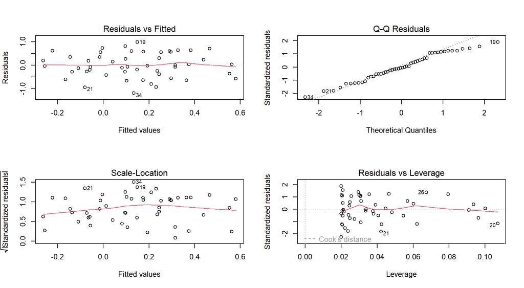

## Model Evaluation in Linear Regression

### .. and now how they should not ..

## Model Evaluation in Linear Regression

### 1. Non-linear relationship

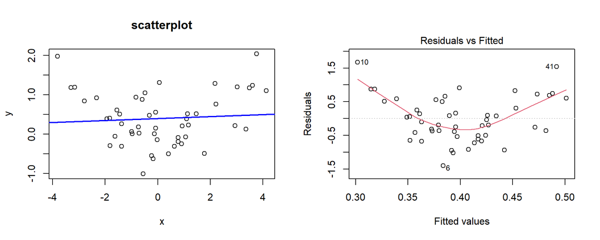

- Try transformations: e.g. \(\tilde x := x^2\)
- Are important explanatory variables missing?

## Model Evaluation in Linear Regression

### 2. Non-normal residuals

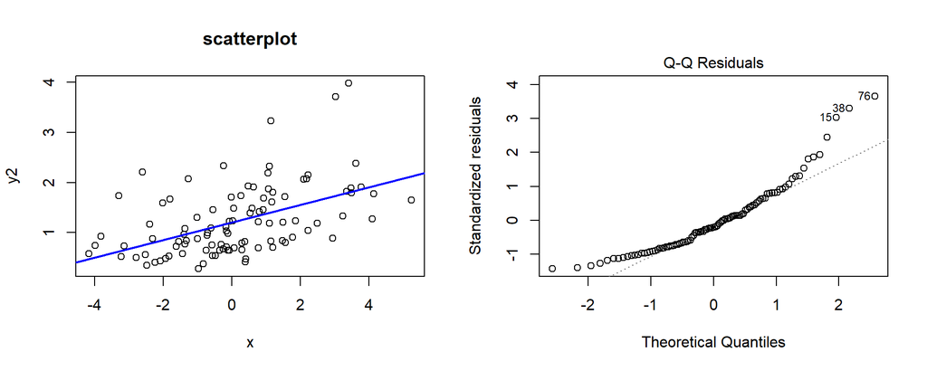

- Try transformations of the response: e.g. \(\tilde y := \text{log} (y)\)
- Are there clusters in the data structure?

## Model Evaluation in Linear Regression

### 3. Non-constant residual variance (Heteroscedasicity)

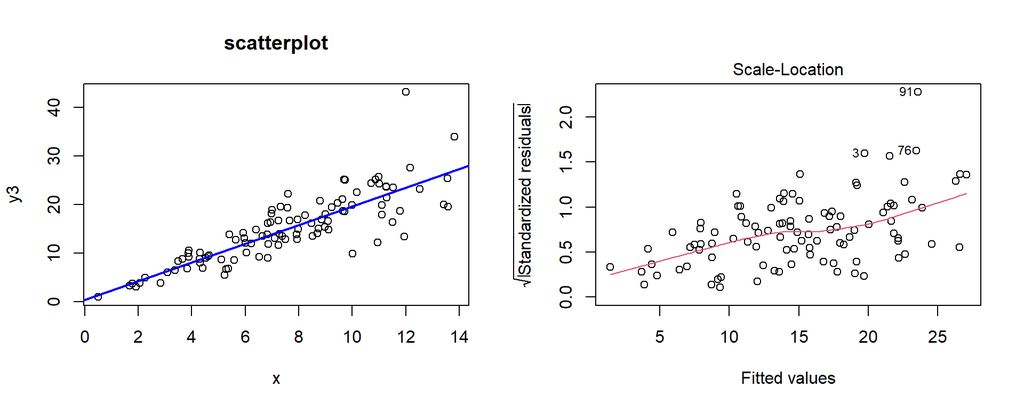

- Try transformation: e.g. \(\tilde x := \text{log} (x)\)
- use heteroscedasticity-consistent estimators for inference (e.g. `lmtest::coeftest()`)

## Model Evaluation in Linear Regression

### 4. Highly Influential Individuals (Outliers)

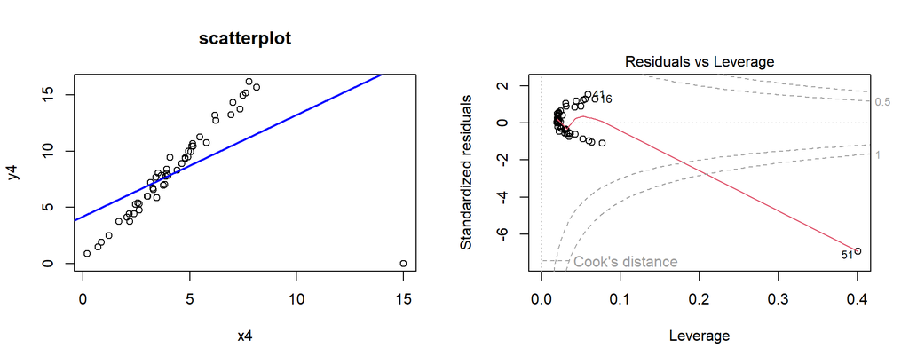

- Check the individual observation *(here 51)* carefully for data errors.
- Redefine inclusion criteria to exclude that observation or apply weights to lessen its effect

## Example `cholesterol`

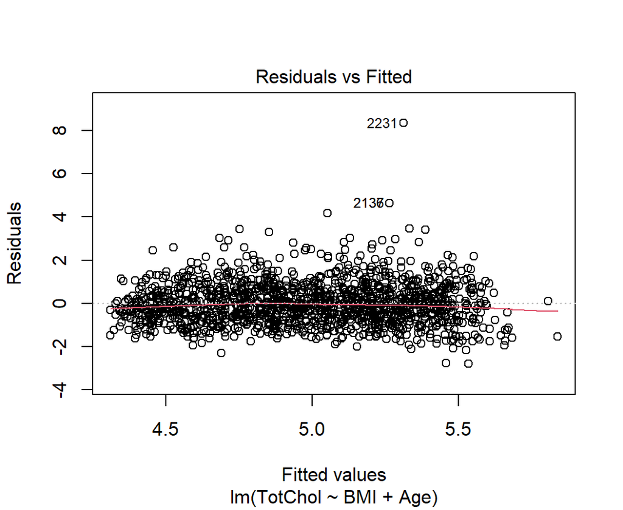

\(\hbox{}\\[4ex]\)

Is there a trend in the residuals?

- looks okayish here

## Example `cholesterol`

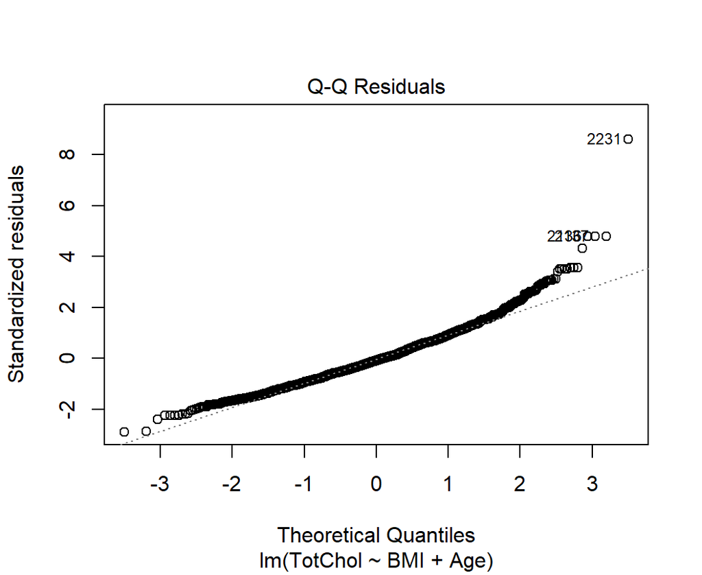

\(\hbox{}\\[4ex]\)

Are the residuals approximately normal?

- not really, positive residuals too large, negative residuals too small
- First step would be to transform the response variable `TotChol` with `log10`

## Example `cholesterol`

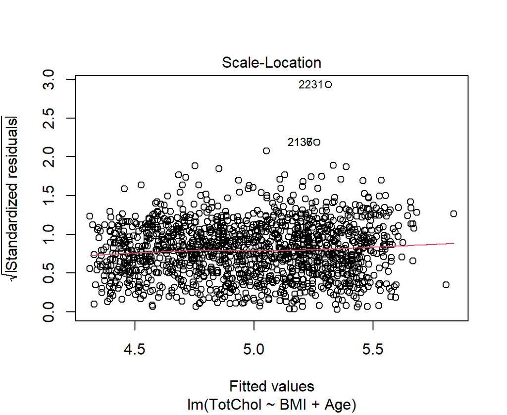

\(\hbox{}\\[4ex]\)

Is the variance approximately constant over the range of \(\widehat f (bmi)\)?

- no trend visible

## Example `cholesterol`

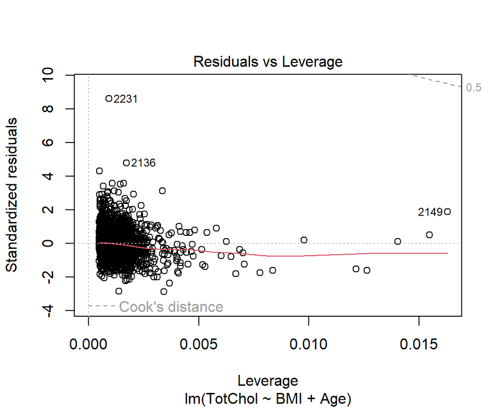

\(\hbox{}\\[4ex]\)

Are there highly influential individuals?

- looks okayish here

## Linear Regression

### Inference in linear regression analysis: t-test

In linear regression, closed formulae for the standard errors of the regression coefficients can be derived.  
In a simple linear model, the standard error of \(\widehat\beta_1\) is: \[ \text{se}_{\widehat\beta_1} = \sqrt{\frac{\frac{1}{n-2}\sum_{i=1}^n {\widehat\epsilon_i}^2} {\sum_{i=1}^n (x_i-\overline x)^2}} \]

This enables us to conduct a t-test with \(n-2\) degrees of freedom \[ t=\frac{\widehat\beta_1 - \beta_1}{\text{se}_{\widehat\beta_1}} \sim t_{n-2} \]

## Linear Regression

### Inference in linear regression analysis: t-test

This is what `summary()` presents. Recap example `cholesterol`:

```
##               Estimate  Std. Error  t value      Pr(>|t|)
## (Intercept) 3.78116611 0.081766302 46.24357 1.976263e-323
## Age         0.03523166 0.002288214 15.39701  8.607269e-51
```

Now calculate the standard error manually:

```r
n       <- dim ( nhanes ) [1]
sq_res  <- sum( (lm1$residuals)^2 ) / (n-2) ## sum of squared residuals
se_b1   <- sqrt( sq_res / (var(lm1$model$Age)*(n-1)) )
se_b0   <- se_b1*sqrt(mean(lm1$model$Age^2))

print( c( se_b0 , se_b1 ))
```

```
## [1] 0.07780721 0.00217742
```

## Linear Regression

### Inference in linear regression analysis: F-test

tests whether the explained variance in the population is greater than zero.

Cohen’s \(f^2\):

\[ f^2 = \frac{R^2}{1-R^2} \qquad = \frac{\text{"explained variance"}}{\text{"unexplained variance"}} \]

This \(f^2\) is \(F\)-distributed \[ f^2 \sim F_{u,v} \]

## Linear Regression

### Inference in linear regression analysis: F-test

If one wants to test whether a second set of variables \(B\) has additional explanatory power beyond a first set of variables \(A\), then \(f^2\) becomes: \[ f^2 = \frac{R_{AB}^2 - R_A^2}{1 - R_{AB}^2} \sim F_{u,v} \] where

- \(u\) equals the number of variables in the second set \(u=p_B\) and
- \(v=n- (p_A + p_B+1)\)

## Sample Size Calculation

### example A

The attitude of patients towards a new treatment \(att\) is investigated. A small pilot study suggests that age is (negatively) correlated with the response attitude; the \(R^2\) of a simple linear regression is \(R^2_{age}=0.1\).

To investigate the alternative hypothesis with an F-Test, that \(age\) contributes to \(att\) in the population, with significance level \(\alpha=0.05\) and power set to 90%, how many persons need to be asked?

## Sample Size Calculation

### example A: \(u=1\), \(R^2=0.1\), \(\alpha=0.05\), \(power=0.9\)

```r
f2 <- (0.1)/(1-0.1)               ## calculate f^2
pwr.f2.test(u=1,f2=f2,power=0.9)  ## F-test
```

```
##
##      Multiple regression power calculation
##
##               u = 1
##               v = 94.52855
##              f2 = 0.1111111
##       sig.level = 0.05
##           power = 0.9
```

- The needed sample size is \(\lceil v \rceil +2=97\)

## Sample Size Calculation

### example B

The effect of education is also suspected to have an influence on the patients attitude. But since education and age are correlated, the aim is to obtain the effect of education only (i.e. the effect of education **adjusted** for age).

## Sample Size Calculation

```r
f2 <- (0.15 - 0.1)/(1 - 0.15)
pwr.f2.test(u=1,f2=f2,power=0.9)
```

```
##
##      Multiple regression power calculation
##
##               u = 1
##               v = 178.5686
##              f2 = 0.05882353
##       sig.level = 0.05
##           power = 0.9
```

- The needed sample size is \(\lceil v \rceil +2 + 1 = 182\)

## Model Assessment Revisited: `DHARMa`-package

- for regression models more complicated than linear regressions, the output of the `plot` function is almost not interpretable.
- simulate from the model many residuals for each observation
- compare the actual residual with the simulated residuals.

## Example `birthwt`

### logistic.model.1

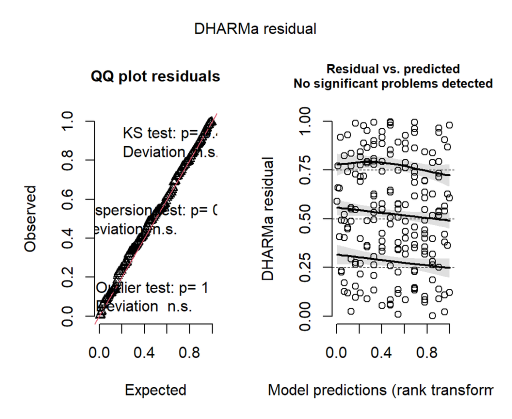

## Example `birthwt`

### logistic.model.2

with `ptl` as a factor variable

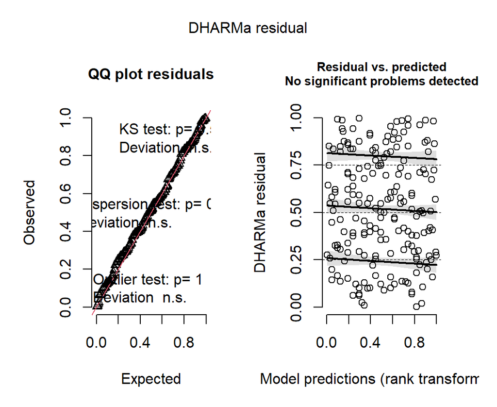

## Example `birthwt`

### logistic.model.2

`ptl` as **metric** variable (not as factor)

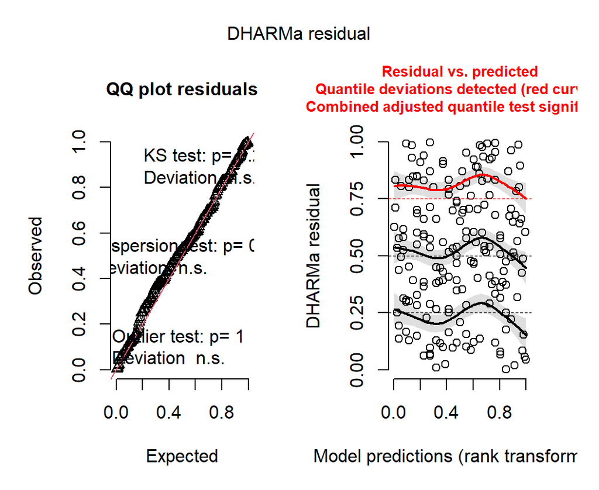

\(\hbox{}\\[4ex]\)

- wiggly trend lines
- too many overly large residuals

## Example `birthwt`

### logistic.model.2a

with `ptl>0`

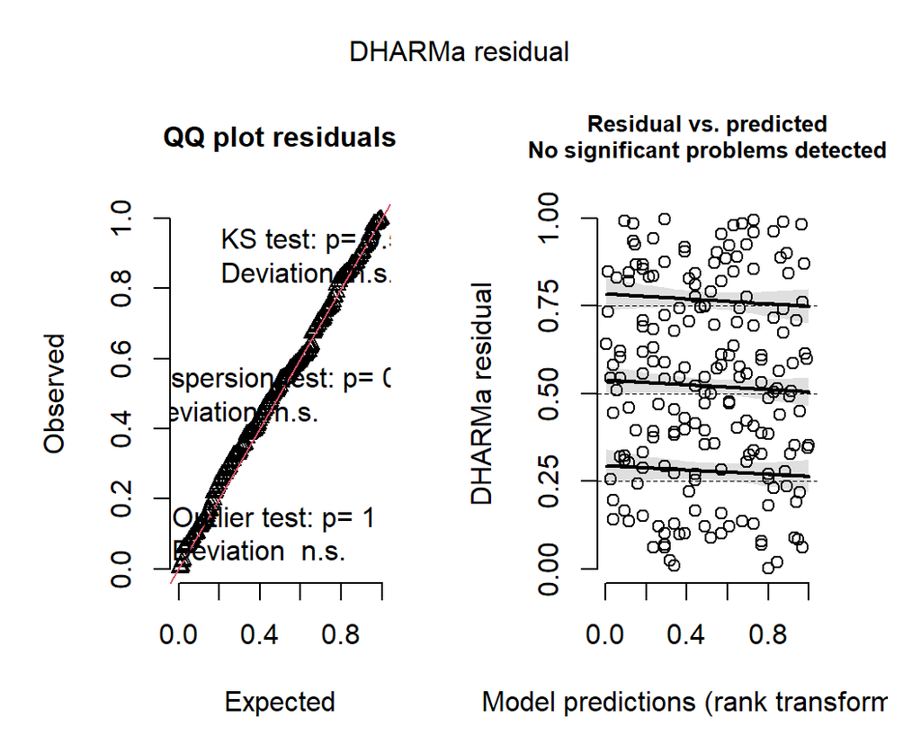

## General Caveats

- don’t get confused with the names:
  - response a.k.a. regressand a.k.a. dependent variable
  - expanatory variables a.k.a. regressors a.k.a. independent variables
- avoid high multicolliniarity in the explanatory variables

## Further reading

- Fox (2016), *Applied Regression Analysis and Generalized Linear Models, Third Edition*
- Fox and Weisberg (2011), *An R Companion to Applied Regression, Second Edition*
- Fahrmeir, Kneip and Lang (2009), *Regression* (german)